# F1 2017 Monaco, Qualifying

Drivers progressed through the qualifying session as follows:

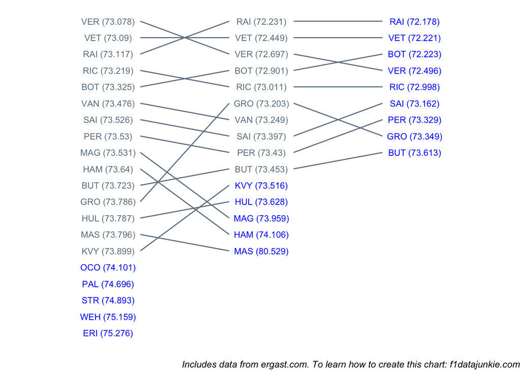

Going from Q1 to Q2:

- MAG failed to improve his time, recording 73.959 compared to 73.531 (0.428s slower)
- HAM failed to improve his time, recording 74.106 compared to 73.64 (0.466s slower)
- MAS failed to improve his time, recording 80.529 compared to 73.796 (6.733s slower)

Going from Q2 to Q3:

- GRO failed to improve his time, recording 73.349 compared to 73.203 (0.146s slower)
- BUT failed to improve his time, recording 73.613 compared to 73.453 (0.16s slower)

Order change going from Q2 to Q3, along with laptime improvement (-ve is a better time in Q3)

```
##   driverName   imp1 driverName   imp2
## 1        BOT -0.678        VER -0.201
## 2        SAI -0.235        GRO  0.146
## 3        PER -0.101        GRO  0.146
```

[figure not shown]

The official session results were recorded as follows:

| POS | DRIVER | Q1 | Q2 | Q3 |
| --- | --- | --- | --- | --- |
| 1 | RAI | 1:13.117 (3) | 1:12.231 (1) | 1:12.178 (1) |
| 2 | VET | 1:13.090 (2) | 1:12.449 (2) | 1:12.221 (2) |
| 3 | BOT | 1:13.325 (5) | 1:12.901 (4) | 1:12.223 (3) |
| 4 | VER | 1:13.078 (1) | 1:12.697 (3) | 1:12.496 (4) |
| 5 | RIC | 1:13.219 (4) | 1:13.011 (5) | 1:12.998 (5) |
| 6 | SAI | 1:13.526 (7) | 1:13.397 (8) | 1:13.162 (6) |
| 7 | PER | 1:13.530 (8) | 1:13.430 (9) | 1:13.329 (7) |
| 8 | GRO | 1:13.786 (12) | 1:13.203 (6) | 1:13.349 (8) |
| 9 | BUT | 1:13.723 (11) | 1:13.453 (10) | 1:13.613 (9) |
| 10 | VAN | 1:13.476 (6) | 1:13.249 (7) |  |
| 11 | KVY | 1:13.899 (15) | 1:13.516 (11) |  |
| 12 | HUL | 1:13.787 (13) | 1:13.628 (12) |  |
| 13 | MAG | 1:13.531 (9) | 1:13.959 (13) |  |
| 14 | HAM | 1:13.640 (10) | 1:14.106 (14) |  |
| 15 | MAS | 1:13.796 (14) | 1:20.529 (15) |  |
| 16 | OCO | 1:14.101 (16) |  |  |
| 17 | PAL | 1:14.696 (17) |  |  |
| 18 | STR | 1:14.893 (18) |  |  |
| 19 | WEH | 1:15.159 (19) |  |  |
| 20 | ERI | 1:15.276 (20) |  |  |

## Session Utilisation

Activity throughout the three qualification sessions took place as follows:

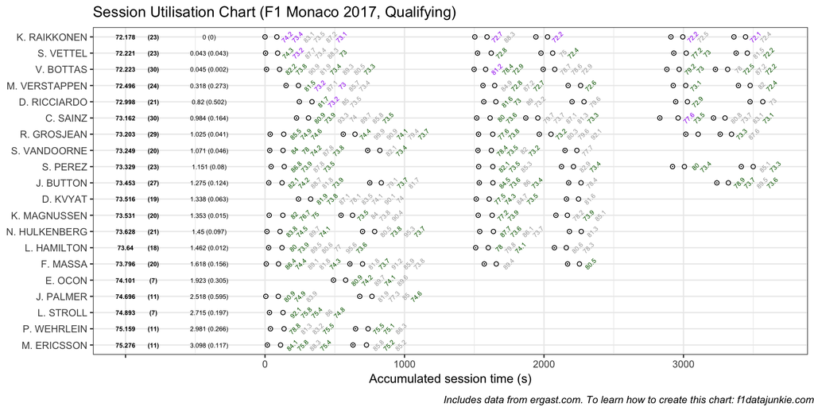

## Q1

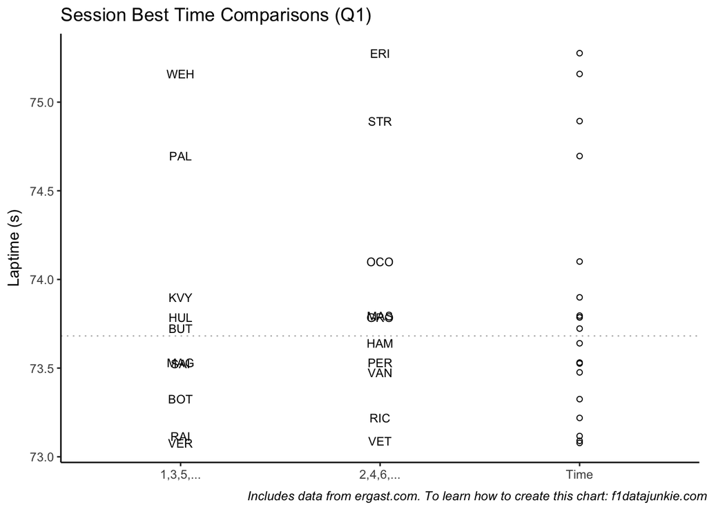

### Cut-off Time Evolution

The cut-off time in Q1 evolved as follows:

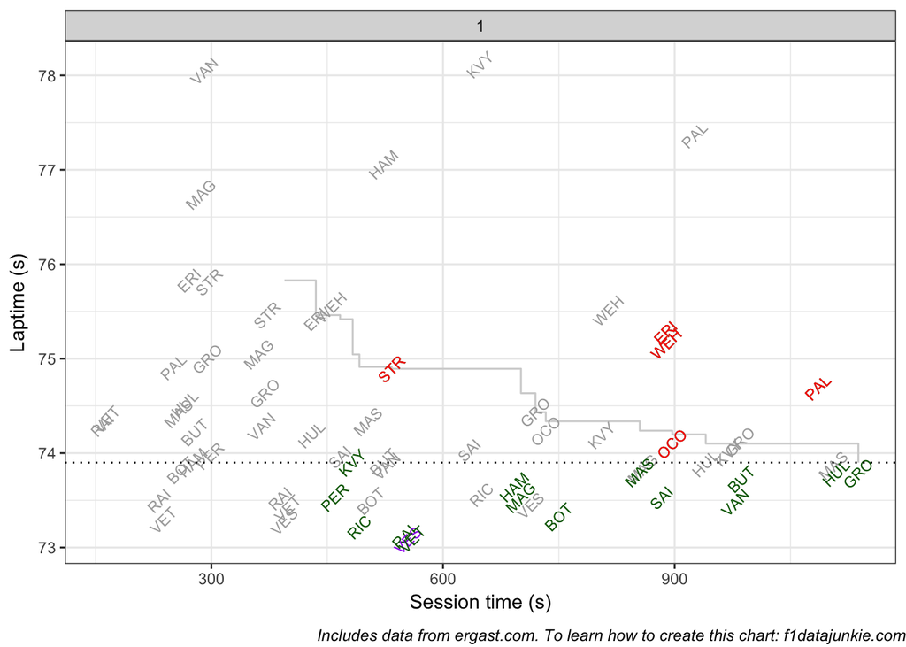

## Q2

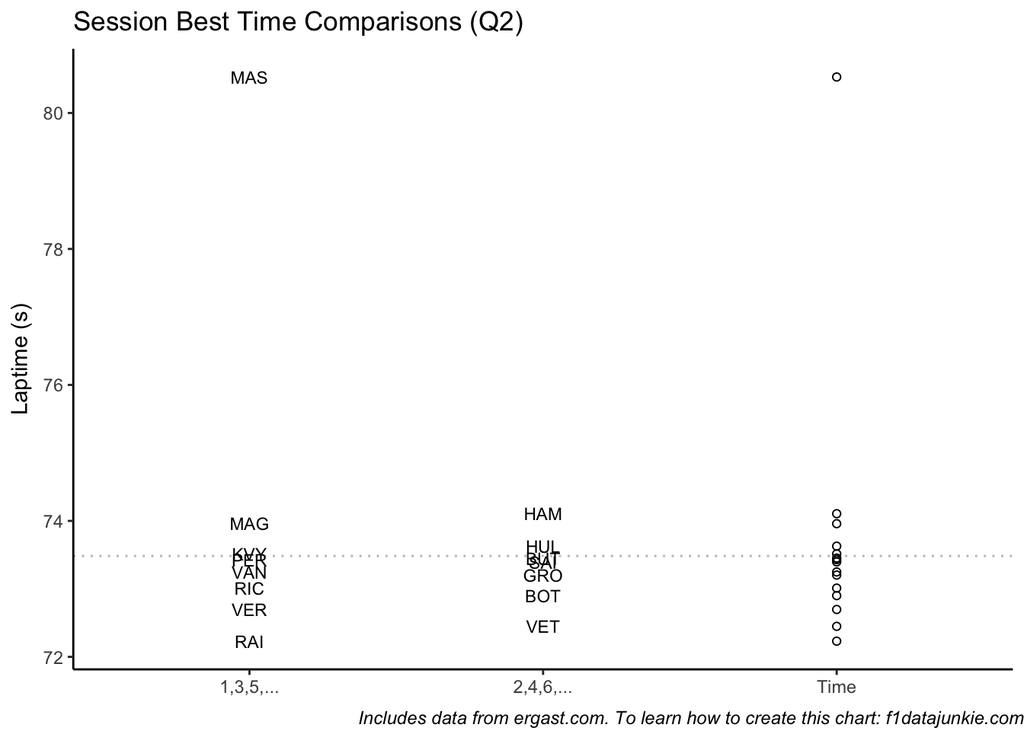

### Cut-off Time Evolution

The cut-off time in Q2 evolved as follows:

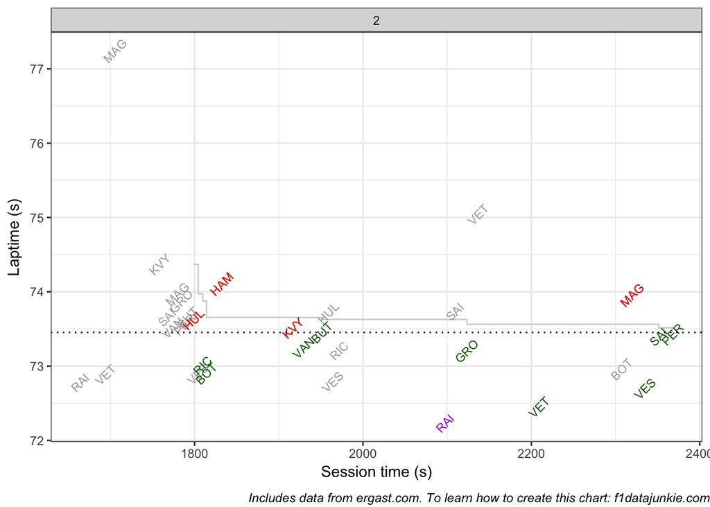

## Q3

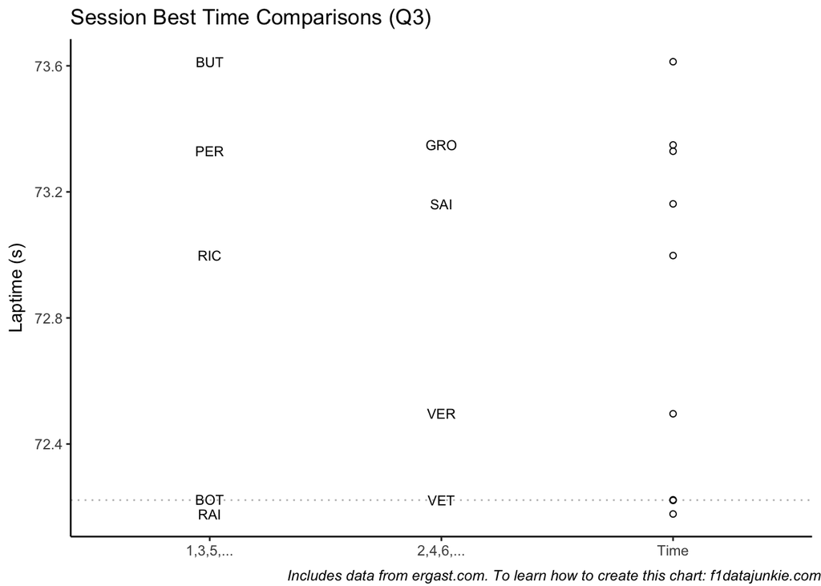

### Front Row Cut-off Time Evolution

The cut-off time in Q3 evolved as follows:

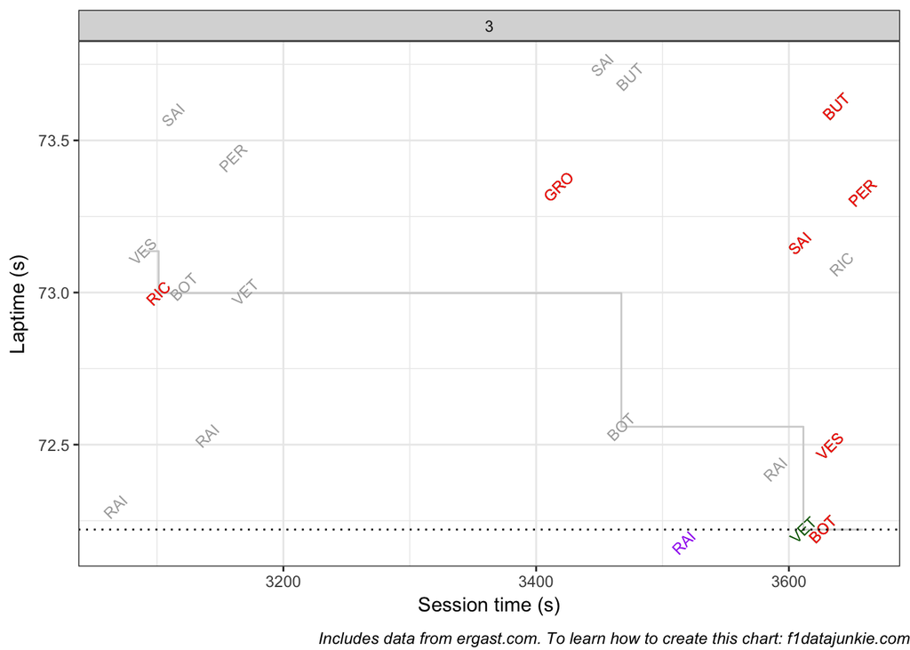

To learn how to wrangle F1 results and timing data to create charts like these, see f1datajunkie.com or [buy the *Wrangling F1 Data With R* book](https://leanpub.com/wranglingf1datawithr).